# Alt Approaches Step 2: Load Raw Technical Replicate Counts

Adam Festa

April 21, 2018

## Script objective

This script preps the raw technical replicate count/experimental data for normalization by:

```
* Removing low expressed counts

* Identifying potential outlier replicates

* Combining counts with complete expermiental meta-data
```

See: analyses/step1.data_prep/README.md for how input data to this script was generated.

## Load data from previous run

- Load the tximport object which contains biological replciates

  ```r
    # tech counts
    load("/media/disk6/ARF/RNASEQ/counts/86kSalmon/tech_rep_txi_count_data_object.RData")
    names(txi)
  ```

  ```
  ## [1] "abundance"           "counts"              "variance"
  ## [4] "length"              "countsFromAbundance"
  ```

  - The txi object is a list of 5 elements containing the counts, bootstrap variance estimates, and effect txpt lengths for each respective sample.
- Load complete experimental meta data

  ```r
    # expt data
    load("/media/disk6/ARF/RNASEQ/Breeding-Value-Prediction/disk6directory/resources/expt.dat.720.RData")
    dim(expt.dat.720)
  ```

  ```
  ## [1] 720  36
  ```

  - The experimental data set contain 720 rows and 36 columns. Each row correspond to a technical replicate and each column corresponds to a piece of meta-deta describing the techincal replicate.

## Connect raw counts and experiment info

- Print the column names of the experimental data frame.

  ```r
  colnames(expt.dat.720)
  ```

  ```
  ##  [1] "animal_id"          "fam_id"             "p1"
  ##  [4] "p2"                 "batch"              "lane"
  ##  [7] "index_seq"          "fl_mean"            "index_let"
  ## [10] "sample_id"          "salmon_input_path"  "p_info"
  ## [13] "Height"             "Height Accuracy"    "Height LB"
  ## [16] "Height UB"          "Volume"             "Volume Accuracy"
  ## [19] "Volume LB"          "Volume UB"          "Rust"
  ## [22] "Rust Accuracy"      "Rust LB"            "Rust UB"
  ## [25] "Rust Grade"         "Strt"               "Strt Accuracy"
  ## [28] "Strt LB"            "Strt UB"            "Strt Grade"
  ## [31] "Fork"               "Fork Accuracy"      "Fork LB"
  ## [34] "Fork UB"            "Fork Grade"         "salmon_output_path"
  ```

- Print names of txi count data. To match them up we will need to paste together the animal id, lane, and index letter from the experiment info data frame.

  ```r
  # print the column names of the counts (biological replicate names)
  head(colnames(txi$counts))
  ```

  ```
  ## [1] "1030.ew_lane03.v" "1028.ew_lane03.c" "1075.ew_lane03.i"
  ## [4] "1087.ew_lane03.w" "1013.ew_lane03.f" "1079.ew_lane03.t"
  ```

  ```r
  # Create a vector of names to match with the counts
    pheno.colnames <- paste(expt.dat.720$animal_id,expt.dat.720$lane,expt.dat.720$index_let,sep = ".")
  # Check for identical names between phenos and counts
    identical(pheno.colnames,colnames(txi$counts))
  ```

  ```
  ## [1] TRUE
  ```

## Pre-filter data and check for outliers

  # Remove low counts from remaining objects in the list
  txi$abundance <- txi$abundance[-c(rm.zero),]
  txi$length <- txi$length[-c(rm.zero),]
  txi$variance <- txi$variance[-c(rm.zero),]
  ```

- Generate pc plot and check outliers

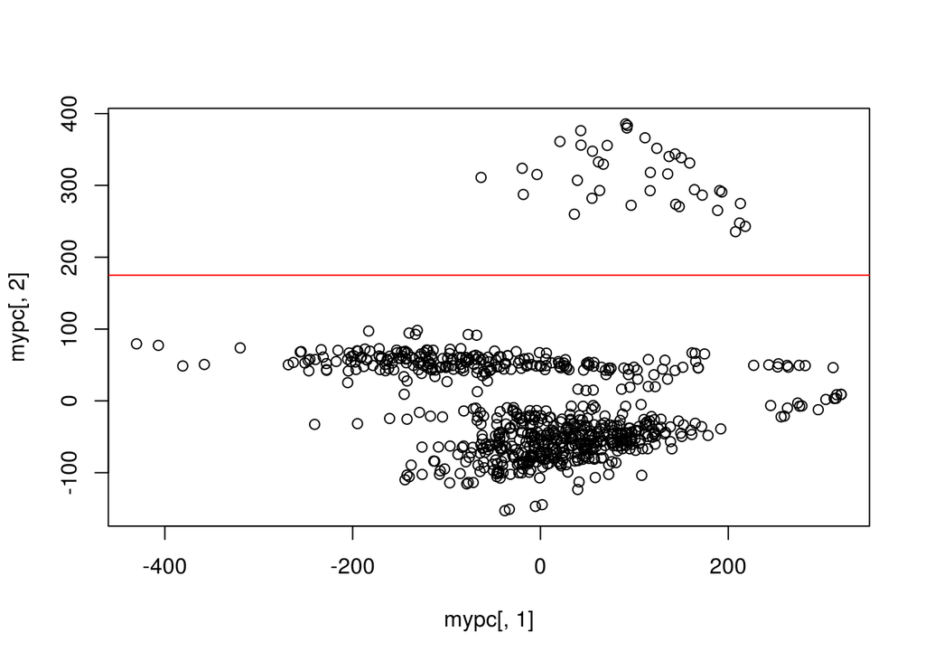

  ```r
  # Use the counts to create a pc plot and plot the first two
  mypc <- prcomp(t(txi$counts),center = T,scale. = T)
  mypc <- mypc$x[,1:2]
  plot(mypc[,1],mypc[,2]); abline(h=175,col="red")
  ```

  ```r
  # Which reps are outliers?
  data.frame("bad.samps" = sort(names(which(mypc[,2] > 175))))
  ```

  ```
  ##           bad.samps
  ## 1  1069.ew_lane04.e
  ## 2  1069.ew_lane05.e
  ## 3  1069.ew_lane12.e
  ## 4  1070.ew_lane03.x
  ## 5  1070.ew_lane08.x
  ## 6  1070.ew_lane12.x
  ## 7  1071.ew_lane01.v
  ## 8  1071.ew_lane06.v
  ## 9  1071.ew_lane12.v
  ## 10 1072.ew_lane04.t
  ## 11 1072.ew_lane05.t
  ## 12 1072.ew_lane11.t
  ## 13 1073.ew_lane01.x
  ## 14 1073.ew_lane06.x
  ```

  [output cut: 25 more lines]

- Remove outlier biological replicates

  ```r
  # Identify the rows which correspond to the outliers
  rm.tech.reps <- which(mypc[,2] > 175)
  # Subset the txi and pheno objects to remove families with less than 3 bio reps per batch
  txi$counts <- txi$counts[,-c(rm.tech.reps)]

  rm.zero <- which(apply(txi$counts,1,sum) < ncol(txi$counts))
  txi$counts <- txi$counts[-c(rm.zero),]
  txi$abundance <- txi$abundance[-c(rm.zero),-c(rm.tech.reps)]
  txi$variance <- txi$variance[-c(rm.zero),-c(rm.tech.reps)]
  txi$length <- txi$length[-c(rm.zero),-c(rm.tech.reps)]

  sub.phenos <- droplevels.data.frame(expt.dat.720[-c(rm.tech.reps),])

  unique(sub.phenos$fam_id)
  ```

  ```
  ##  [1] N111095         WG7720          WG7442          WG7206
  ##  [5] N07058          N08103          N08059          N101027
  ##  [9] WG1809          WG4501          LSG111          N111062
  ## [13] WG7478          WG7083          N051501         N12008
  ## [17] WG7192          WG4801          N22204          N22269
  ## [21] N08001          WG4302          N08061          N07056
  ## [25] N07105          N051049         N22212          N07100
  ## [29] N071084         N111111         N091083xN25063  N25073
  ## [33] N11061          N11010          N111027         N10005
  ## [37] N22010          N22005          N10010          N22029
  ## [41] N22044          N111111xC21B    N22063          N101029
  ## [45] N25064          N22033          N25075          N111069
  ## [49] N10005xUC       N111066         N26004          N22029xB48
  ## [53] N02005          N22057          N071037         N26001
  ## [57] N25070          N22055          N081072         N091083
  ## [61] N11016          N22010xN22037   N10010xB21      N071011
  ## [65] N071096         N25073xBA2L20   N091019         N081072xN101047
  ## [69] N22024          N07002
  ## 70 Levels: LSG111 N02005 N051049 N051501 N07002 N07056 N07058 ... WG7720
  ```

- Generate pc plot and check outliers

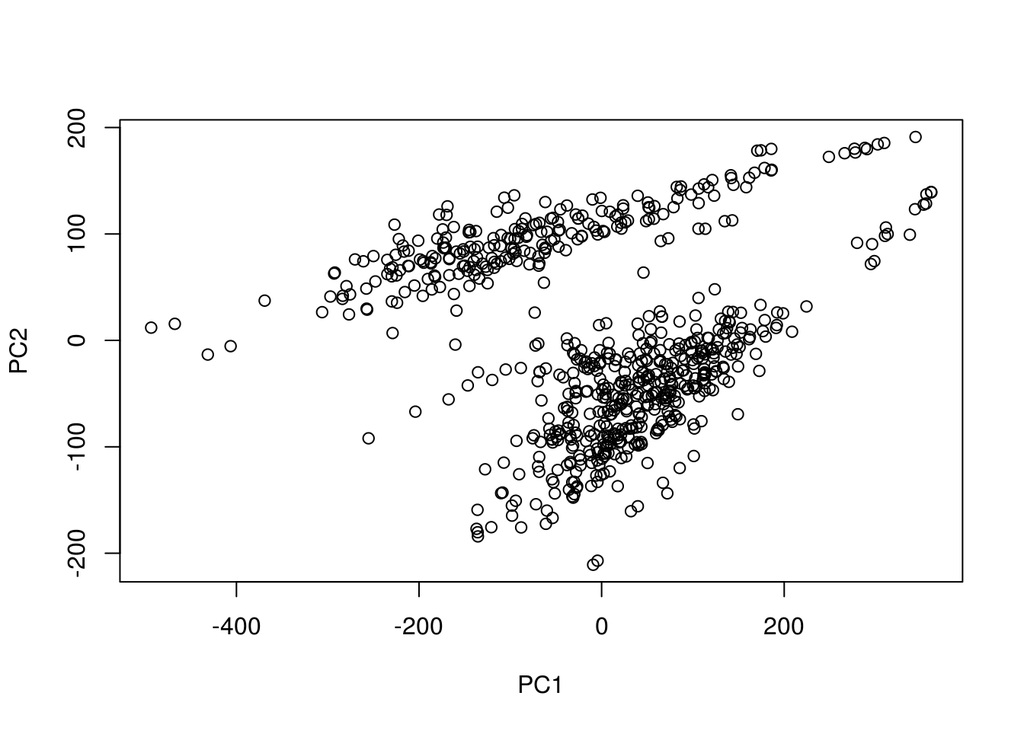

  ```r
  # Use the counts to create a pc plot and plot the first two
  mypc <- prcomp(t(txi$counts),center = T,scale. = T)
  mypc <- mypc$x[,1:2]
  plot(mypc)
  ```

  - The EW and LGEP are parallel to one another on the plot above. How would the samples look if we created a PC plot using only the LGEP or EW?

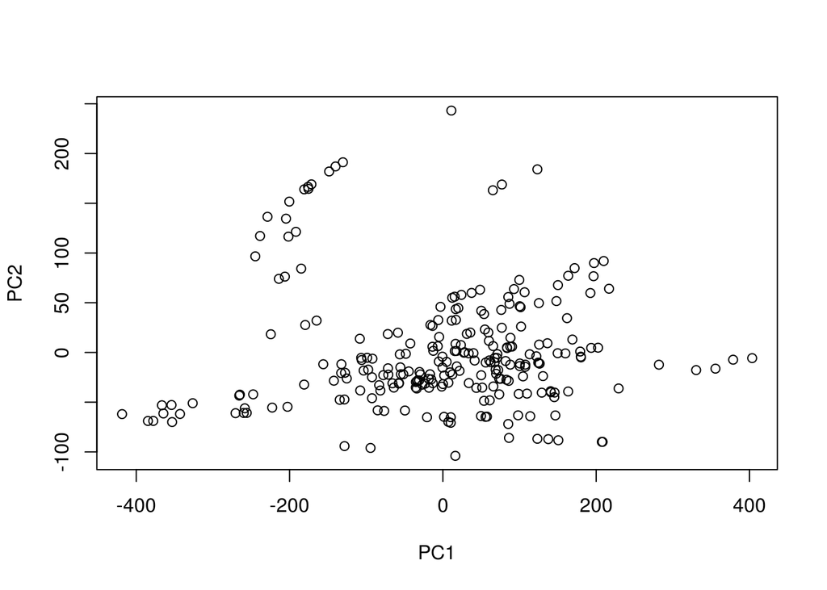

  ```r
  ew.reps <- which(sub.phenos$batch == "EW")
  ew.cts <- txi$counts[,ew.reps]
  rm.zero <- which(apply(ew.cts,1,sum) <= ncol(ew.cts))
  ew.cts <- ew.cts[-c(rm.zero),]

  mypc <- prcomp(t(ew.cts),center = T,scale. = T)
  mypc <- mypc$x[,1:2]
  plot(mypc)
  ```

  ```r
  sort(names(which(mypc[,1] < -250)))
  ```

  ```
  ##  [1] "1001.ew_lane04.j" "1001.ew_lane05.j" "1001.ew_lane10.j"
  ##  [4] "1002.ew_lane04.s" "1002.ew_lane08.s" "1002.ew_lane09.s"
  ##  [7] "1003.ew_lane02.c" "1003.ew_lane07.c" "1003.ew_lane12.c"
  ## [10] "1004.ew_lane10.n" "1026.ew_lane03.h" "1026.ew_lane06.h"
  ## [13] "1026.ew_lane09.h" "1051.ew_lane02.p" "1051.ew_lane08.p"
  ```

  ```r
  sort(names(which(mypc[,1] < -100 & mypc[,2] > 50)))
  ```

  ```
  ##  [1] "1036.ew_lane02.l" "1036.ew_lane05.l" "1036.ew_lane09.l"
  ##  [4] "1037.ew_lane06.j" "1037.ew_lane12.j" "1038.ew_lane04.o"
  ##  [7] "1038.ew_lane05.o" "1038.ew_lane11.o" "1045.ew_lane02.i"
  ## [10] "1045.ew_lane06.i" "1045.ew_lane10.i" "1047.ew_lane04.n"
  ## [13] "1047.ew_lane05.n" "1047.ew_lane11.n" "1048.ew_lane01.k"
  ## [16] "1048.ew_lane08.k" "1048.ew_lane10.k"
  ```

  - Now look at LGEP:

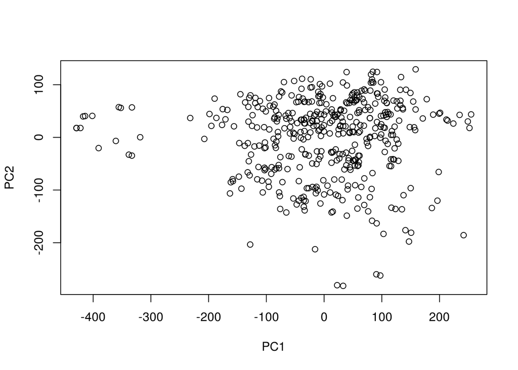

  ```r
  lgep.reps <- which(sub.phenos$batch == "LGEP")
  lgep.cts <- txi$counts[,lgep.reps]
  rm.zero <- which(apply(lgep.cts,1,sum) <= ncol(lgep.cts))
  lgep.cts <- lgep.cts[-c(rm.zero),]

  mypc <- prcomp(t(lgep.cts),center = T,scale. = T)
  mypc <- mypc$x[,1:2]
  plot(mypc)
  ```

  ```r
  sort(names(which(mypc[,1] < -225)))
  ```

  ```
  ##  [1] "10.lane01.p"  "10.lane10.p"  "10.lane17.p"  "117.lane07.v"
  ##  [5] "133.lane02.a" "133.lane09.a" "133.lane16.a" "13.lane02.f"
  ##  [9] "13.lane10.f"  "13.lane14.f"  "15.lane09.m"  "37.lane15.d"
  ## [13] "67.lane02.c"  "67.lane10.c"  "67.lane14.c"
  ```

- Probably should keep an eye on the above samples, but prior to normalization there is nothing to suggest that these samples are “bad”

## Save output

- Now let’s save the objects which will be used for normalization

  ```r
  load.counts_tech <- vector("list")
  load.counts_tech$txi_object <- txi
  load.counts_tech$phenos <- sub.phenos

  save(load.counts_tech,file="/media/disk6/ARF/RNASEQ/counts/86kSalmon/Step2_TECH_Load_Counts.RData",compress=T)
  ```